# 케라스 텍스트 처리 및 임베딩

- 코드 참조: 케라스 창시자에게 배우는 딥러닝

## 용어 설명

- `토큰(token)`
  - **텍스트를 나누는 단위**
  - 토큰화(tokenization): 토큰으로 나누는 작업
- `n-gram`
  - 문장에서 추출한 N개(또는 그 이하)의 연속된 단어 그룹
  - 같은 개념이 '문자'에도 적용가능

[figure not shown]

  <sub>출처: https://www.sqlservercentral.com/articles/nasty-fast-n-grams-part-1-character-level-unigrams</sub>

```python
import numpy as np
```

```python
samples = ['The cat sat on the mat.',
           'The dog ate my homeworks.']
token_index = {}
```

```python
for sample in samples:
  for word in sample.split():
    if word not in token_index:
      token_index[word] = len(token_index) + 1

max_len = 10
results = np.zeros(shape=(len(samples), max_len,
                          max(token_index.values()) + 1))
```

```python
for i, sample in enumerate(samples):
  for j, word in list(enumerate(sample.split()))[:max_len]:
    index = token_index.get(word)
    results[i, j, index] = 1.

results
```

```
array([[[0., 1., 0., 0., 0., 0., 0., 0., 0., 0., 0.],
        [0., 0., 1., 0., 0., 0., 0., 0., 0., 0., 0.],
        [0., 0., 0., 1., 0., 0., 0., 0., 0., 0., 0.],
        [0., 0., 0., 0., 1., 0., 0., 0., 0., 0., 0.],
        [0., 0., 0., 0., 0., 1., 0., 0., 0., 0., 0.],
        [0., 0., 0., 0., 0., 0., 1., 0., 0., 0., 0.],
        [0., 0., 0., 0., 0., 0., 0., 0., 0., 0., 0.],
        [0., 0., 0., 0., 0., 0., 0., 0., 0., 0., 0.],
        [0., 0., 0., 0., 0., 0., 0., 0., 0., 0., 0.],
        [0., 0., 0., 0., 0., 0., 0., 0., 0., 0., 0.]],

       [[0., 1., 0., 0., 0., 0., 0., 0., 0., 0., 0.],
        [0., 0., 0., 0., 0., 0., 0., 1., 0., 0., 0.],
        [0., 0., 0., 0., 0., 0., 0., 0., 1., 0., 0.],
        [0., 0., 0., 0., 0., 0., 0., 0., 0., 1., 0.],
        [0., 0., 0., 0., 0., 0., 0., 0., 0., 0., 1.],
        [0., 0., 0., 0., 0., 0., 0., 0., 0., 0., 0.],
        [0., 0., 0., 0., 0., 0., 0., 0., 0., 0., 0.],
        [0., 0., 0., 0., 0., 0., 0., 0., 0., 0., 0.],
        [0., 0., 0., 0., 0., 0., 0., 0., 0., 0., 0.],
        [0., 0., 0., 0., 0., 0., 0., 0., 0., 0., 0.]]])
```

## 케라스를 사용한 단어 수준 원-핫 인코딩

#### `tensorflow.keras.preprocessing.text.Tokenizer(num_words, oov_token)`

- `OOV` : Out of Vocabulary
  - `oov_token=<OOV>` $→$ 새로운 문장에서 기존에 토큰화한 문장에 존재하지 않으면 OOV로 대체됨

#### `토크나이저객체.fit_on_texts()`

#### `토크나이저객체.texts_to_sequences()`

#### `토크나이저객체.texts_to_matrix()`

```python
from tensorflow.keras.preprocessing.text import Tokenizer
```

```python
samples = ['The cat sat on the mat.',
           'The dog ate my homeworks.']

tokenizer = Tokenizer(num_words=10)
tokenizer.fit_on_texts(samples)

sequences = tokenizer.texts_to_sequences(samples)

ohe_results = tokenizer.texts_to_matrix(samples, mode='binary')

word_index = tokenizer.word_index
print(len(word_index))
```

```
9
```

```python
sequences
```

```
[[1, 2, 3, 4, 1, 5], [1, 6, 7, 8, 9]]
```

```python
print(ohe_results.shape)
print(ohe_results)
```

```
(2, 10)
[[0. 1. 1. 1. 1. 1. 0. 0. 0. 0.]
 [0. 1. 0. 0. 0. 0. 1. 1. 1. 1.]]
```

```python
word_index
```

```
{'the': 1,
 'cat': 2,
 'sat': 3,
 'on': 4,
 'mat': 5,
 'dog': 6,
 'ate': 7,
 'my': 8,
 'homeworks': 9}
```

### 토큰화 예제

```python
from tensorflow.keras.preprocessing.text import Tokenizer
```

```python
samples = ["I'm the smartest student.",
           "I'm the best student."]

tokenizer = Tokenizer(num_words=10, oov_token='<OOV>')
tokenizer.fit_on_texts(samples)

sequences = tokenizer.texts_to_sequences(samples)

binary_results = tokenizer.texts_to_matrix(samples, mode='binary')

print(tokenizer.word_index)
```

```
{'<OOV>': 1, "i'm": 2, 'the': 3, 'student': 4, 'smartest': 5, 'best': 6}
```

```python
binary_results
```

```
array([[0., 0., 1., 1., 1., 1., 0., 0., 0., 0.],
       [0., 0., 1., 1., 1., 0., 1., 0., 0., 0.]])
```

테스트

```python
test = ["I'm the fastest person."]
test_seq = tokenizer.texts_to_sequences(test)
```

```python
print("word_index: ",word_index)
print("Test Text: ", test)
print("Test Seq: ", test_seq)
```

```
word_index:  {'the': 1, 'cat': 2, 'sat': 3, 'on': 4, 'mat': 5, 'dog': 6, 'ate': 7, 'my': 8, 'homeworks': 9}
Test Text:  ["I'm the fastest person."]
Test Seq:  [[2, 3, 1, 1]]
```

## 원-핫 단어 벡터와 단어 임베딩

- **`원-핫 단어 벡터`**
  - 데이터가 희소(sparse)
  - 고차원
- **`단어 임베딩`**
  - 밀집(dense)
  - 저차원

[figure not shown]

  <sub>출처: https://freecontent.manning.com/deep-learning-for-text/</sub>

## 단어 임베딩

- **단어간 벡터사이의 거리가 가까운, 즉 비슷한 단어들끼리 임베딩**
- 거리 외에 임베딩 공간의 특정 방향도 의미를 가질 수 있음

[figure not shown]

<sub>출처: https://towardsdatascience.com/creating-word-embeddings-coding-the-word2vec-algorithm-in-python-using-deep-learning-b337d0ba17a8</sub>

## Embedding Layer

#### `tensorflow.keras.layers.Embedding(samples, sequence_length)`

- 특정 단어를 나타내는 정수 인덱스를 밀집 벡터(dense vector)로 매핑하는 딕셔너리 레이어
- 입력: `(samples, sequence_length)`
- 출력: `(samples, sequnece_length, dim)`

```python
from tensorflow.keras.layers import Embedding
```

```python
embedding_layer = Embedding(1000, 64)
embedding_layer
```

```
<keras.layers.core.embedding.Embedding at 0x7f1d6b93a2f0>
```

## 예제 : IMDB 데이터

- 인터넷 영화 데이터베이스(Internet Movie Database)
- 양극단의 리뷰 5만개로 이루어진 데이터셋
  - 훈련데이터: 25,000개
  - 테스트데이터 : 25,000개

[figure not shown]

- https://www.imdb.com/interfaces/

### module import

```python
from tensorflow.keras.datasets import imdb
from tensorflow.keras.models import Sequential
from tensorflow.keras.layers import Embedding, Dense, Flatten
```

### 데이터 로드

```python
num_words = 1000
max_len = 20

(x_train, y_train), (x_test, y_test) = imdb.load_data(num_words=num_words)
```

```
Downloading data from https://storage.googleapis.com/tensorflow/tf-keras-datasets/imdb.npz
```

```python
print(x_train.shape)
print(x_test.shape)
print(y_train.shape)
print(y_test.shape)
```

```
(25000,)
(25000,)
(25000,)
(25000,)
```

### 데이터 확인

- 긍정: 1
- 부정: 0

```python
print(y_train[0])
```

```
1
```

```python
for i in range(10):
  if y_train[i] == 0:
    label = "부정"
  else:
    label = "긍정"

  print(y_train[i], label)
```

```
1 긍정
0 부정
0 부정
1 긍정
0 부정
0 부정
1 긍정
0 부정
1 긍정
0 부정
```

### (참고) IMDB 데이터셋에서 가장 많이 사용된 단어

```python
word_index = {}

for key, val in imdb.get_word_index().items():
  word_index[val] = key

for i in range(1, 6):
  print(word_index[i])
```

```
the
and
a
of
to
```

### 데이터 전처리

#### `tensorflow.keras.preprocessing.sequence.pad_sequences(sequences, maxlen, padding)`

- 모든 데이터를 같은 길이로 맞추기
  - `pad_sequence()`
    - **데이터가 maxlen보다 길면 데이터를 자름**
    - **데이터가 길면 `padding` 설정**
      - **`pre`**: 데이터 앞에 0으로 채움
      - **`post`**: 데이터 뒤에 0으로 채움
- **모든 데이터(문장 하나하나)가 같은 길이로 맞춰저야 `Embedding` 레이어를 사용할 수 있음**

```python
from tensorflow.keras.preprocessing.sequence import pad_sequences
```

```python
pad_x_train = pad_sequences(x_train, maxlen=max_len, padding='pre')
pad_x_test = pad_sequences(x_train, maxlen=max_len, padding='pre')
```

```python
print(len(x_train[0]))
print(len(pad_x_train[0]))
```

```
218
20
```

### 모델 구성

```python
model = Sequential()

model.add(Embedding(input_dim=num_words, output_dim=32,
                    input_length=max_len))
model.add(Flatten())
model.add(Dense(1, activation='sigmoid'))

model.summary()
```

```
Model: "sequential"
_________________________________________________________________
 Layer (type)                Output Shape              Param #
=================================================================
 embedding_1 (Embedding)     (None, 20, 32)            32000

 flatten (Flatten)           (None, 640)               0

 dense (Dense)               (None, 1)                 641

=================================================================
Total params: 32,641
Trainable params: 32,641
Non-trainable params: 0
_________________________________________________________________
```

### 모델 컴파일 및 학습

```python
model.compile(optimizer='rmsprop', loss='binary_crossentropy', metrics=['acc'])
```

```python
history = model.fit(pad_x_train, y_train,
                    batch_size=32, epochs=10,
                    validation_split=0.2, verbose=False)
```

### 시각화

```python
import matplotlib.pyplot as plt
```

```python
hist_dict = history.history
hist_dict.keys()
```

```
dict_keys(['loss', 'acc', 'val_loss', 'val_acc'])
```

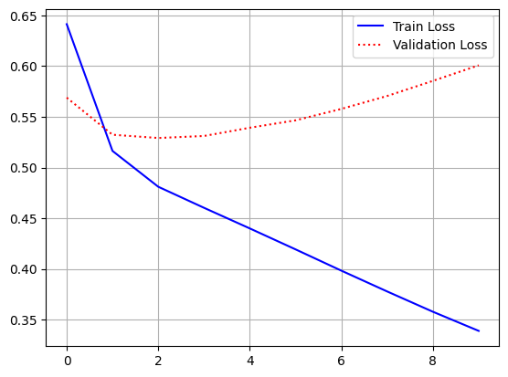

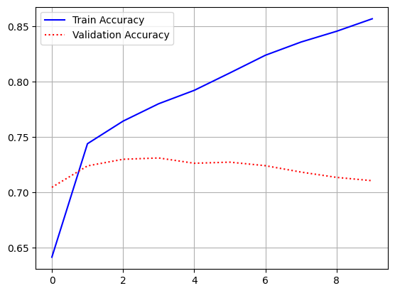

```python
plt.plot(hist_dict['loss'], 'b-', label='Train Loss')
plt.plot(hist_dict['val_loss'], 'r:', label='Validation Loss')
plt.legend()
plt.grid()

plt.figure()
plt.plot(hist_dict['acc'], 'b-', label='Train Accuracy')
plt.plot(hist_dict['val_acc'], 'r:', label='Validation Accuracy')
plt.legend()
plt.grid()

plt.show()
```

### 모델 평가

```python
model.evaluate(pad_x_test, y_test)
```

```
[1.3142902851104736, 0.49540001153945923]
```

```python
num_words = 1000
max_len = 500

pad_x_train_2 = pad_sequences(x_train, maxlen = max_len, padding='pre')
pad_x_test_2 = pad_sequences(x_test, maxlen = max_len, padding='pre')
```

데이터 확인

```python
print(pad_x_train_2[0])
```

```
[  0   0   0   0   0   0   0   0   0   0   0   0   0   0   0   0   0   0
   0   0   0   0   0   0   0   0   0   0   0   0   0   0   0   0   0   0
   0   0   0   0   0   0   0   0   0   0   0   0   0   0   0   0   0   0
   0   0   0   0   0   0   0   0   0   0   0   0   0   0   0   0   0   0
   0   0   0   0   0   0   0   0   0   0   0   0   0   0   0   0   0   0
   0   0   0   0   0   0   0   0   0   0   0   0   0   0   0   0   0   0
   0   0   0   0   0   0   0   0   0   0   0   0   0   0   0   0   0   0
   0   0   0   0   0   0   0   0   0   0   0   0   0   0   0   0   0   0
   0   0   0   0   0   0   0   0   0   0   0   0   0   0   0   0   0   0
   0   0   0   0   0   0   0   0   0   0   0   0   0   0   0   0   0   0
   0   0   0   0   0   0   0   0   0   0   0   0   0   0   0   0   0   0
   0   0   0   0   0   0   0   0   0   0   0   0   0   0   0   0   0   0
   0   0   0   0   0   0   0   0   0   0   0   0   0   0   0   0   0   0
   0   0   0   0   0   0   0   0   0   0   0   0   0   0   0   0   0   0
   0   0   0   0   0   0   0   0   0   0   0   0   0   0   0   0   0   0
   0   0   0   0   0   0   0   0   0   0   0   0   1  14  22  16  43 530
 973   2   2  65 458   2  66   2   4 173  36 256   5  25 100  43 838 112
  50 670   2   9  35 480 284   5 150   4 172 112 167   2 336 385  39   4
 172   2   2  17 546  38  13 447   4 192  50  16   6 147   2  19  14  22
   4   2   2 469   4  22  71  87  12  16  43 530  38  76  15  13   2   4
  22  17 515  17  12  16 626  18   2   5  62 386  12   8 316   8 106   5
   4   2   2  16 480  66   2  33   4 130  12  16  38 619   5  25 124  51
  36 135  48  25   2  33   6  22  12 215  28  77  52   5  14 407  16  82
   2   8   4 107 117   2  15 256   4   2   7   2   5 723  36  71  43 530
 476  26 400 317  46   7   4   2   2  13 104  88   4 381  15 297  98  32
   2  56  26 141   6 194   2  18   4 226  22  21 134 476  26 480   5 144
  30   2  18  51  36  28 224  92  25 104   4 226  65  16  38   2  88  12
  16 283   5  16   2 113 103  32  15  16   2  19 178  32]
```

```python
model = Sequential()

model.add(Embedding(input_dim=num_words, output_dim=32,
                    input_length=max_len))
model.add(Flatten())
model.add(Dense(1, activation='sigmoid'))

model.summary()

model.compile(optimizer='rmsprop', loss='binary_crossentropy', metrics=['acc'])

history2 = model.fit(pad_x_train_2, y_train,
                    batch_size=32, epochs=10,
                    validation_split=0.2, verbose=False)
```

```
Model: "sequential_1"
_________________________________________________________________
 Layer (type)                Output Shape              Param #
=================================================================
 embedding_2 (Embedding)     (None, 500, 32)           32000

 flatten_1 (Flatten)         (None, 16000)             0

 dense_1 (Dense)             (None, 1)                 16001

=================================================================
Total params: 48,001
Trainable params: 48,001
Non-trainable params: 0
_________________________________________________________________
```

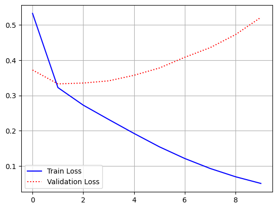

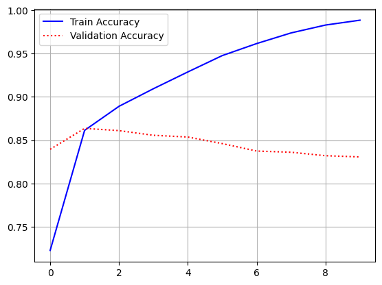

```python
hist_dict2 = history2.history

plt.plot(hist_dict2['loss'], 'b-', label='Train Loss')
plt.plot(hist_dict2['val_loss'], 'r:', label='Validation Loss')
plt.legend()
plt.grid()

plt.figure()
plt.plot(hist_dict2['acc'], 'b-', label='Train Accuracy')
plt.plot(hist_dict2['val_acc'], 'r:', label='Validation Accuracy')
plt.legend()
plt.grid()

plt.show()
```

```python
model.evaluate(pad_x_test_2, y_test)
```

```
[0.5144031643867493, 0.8301600217819214]
```

위의 결과도 나쁘지 않으나 과적합이 되는 이유

- **단어간 관계나 문장 구조 등 의미적 연결을 고려하지 않음**
- **시퀀스 전체를 고려한 특성을 학습하는 것은 `Embedding`층 위에 `RNN`층이나 `1D 합성곱`을 추가하는 것이 좋음**

## 단어 임베딩의 종류

- **LSA**
- **Word2Vec**
- **GloVe**
- **FastText**
- etc..

## Word2Vec

- 2013년, Mikolov 와 동료들이 제안한 모형
- 분류 등과 같이 별도의 레이블이 없이 텍스트 자체만 있어도 학습이 가능
- **Word2Vec의 방식 : 주변 단어의 관계를 이용**

### **CBOW(continuous bag-of-words)**

- **주변단어의 임베딩을 더해서 대상단어를 예측**

### **Skip-Gram**

- **대상 단어의 임베딩으로 주변단어를 예측**
- **일반적으로 CBOW보다 성능이 좋은 편**
- 한번에 여러 단어를 예측해야하기 때문에 비효율적 최근에는 **negative sampling**이라는 방법을 사용

[figure not shown]

<sub>출처: https://www.researchgate.net/figure/CBOW-and-Skip-Gram-neural-architectures_fig14_328160770</sub>

### 구텐베르크 프로젝트 예제

- 코드 출처 : http://doc.mindscale.kr/km/unstructured/11.html

```python
import re
import requests
```

### 데이터 다운로드

```python
res = requests.get('https://www.gutenberg.org/files/2591/2591-0.txt')
```

### 데이터 전처리

```python
grimm = res.text[2801:530661]
grimm = re.sub(r'[^a-zA-Z\.]', ' ', grimm)
sentences = grimm.split('. ')
data = [s.split() for s in sentences]
```

```python
len(data)
```

```
3468
```

```python
print(data[1])
```

```
['These', 'apples', 'were', 'always', 'counted', 'and', 'about', 'the', 'time', 'when', 'they', 'began', 'to', 'grow', 'ripe', 'it', 'was', 'found', 'that', 'every', 'night', 'one', 'of', 'them', 'was', 'gone']
```

#### `gensim` 패키지로부터 WordVec을 불러오기

#### `gensim.models.word2vec.Word2Vec(sentences, sg, size, window, min_count)`

- `sg` : 0이면 CBOW / 1이면 Skip-gram
- `window` : 단어의 앞-뒤 몇 개를 예측에 사용할 것인지에 대한 인자
- `min_count` : 사용할 단어의 최소 빈도
- `vector_size` : 출력 단어 벡터 크기

```python
from gensim.models.word2vec import Word2Vec
```

```python
model = Word2Vec(data, sg=1, vector_size=100, window=3, min_count=3, workers=4)
```

### 모델 저장 및 로드

```python
model.save('word2vec.model')
```

```python
pretrained_model = Word2Vec.load('word2vec.model')
```

### 단어를 벡터로 변환

- `wv`

```python
pretrained_model.wv['princess']
```

```
array([-0.20510982,  0.13694829, -0.10146306,  0.11463961,  0.04821337,
       -0.3428488 ,  0.11758019,  0.5649146 , -0.23535144, -0.24754554,
        0.06159627, -0.31159925,  0.00929542,  0.06929452,  0.125119  ,
       -0.19913696,  0.04993799, -0.16222104, -0.13985269, -0.1535027 ,
        0.27226496,  0.16004029,  0.23164733, -0.13934277,  0.01725279,
       -0.06256098,  0.03950079, -0.05519919, -0.06841113, -0.08969745,
        0.02117519, -0.12170137,  0.13749617, -0.18961959, -0.18544674,
        0.23336089,  0.01297192, -0.08632857, -0.03753753, -0.13906288,
        0.05614814, -0.09015931, -0.01332656,  0.09653796, -0.03771596,
        0.03091081, -0.1173244 , -0.08456544,  0.18715471,  0.02777881,
        0.09708285, -0.07535978, -0.0745008 , -0.17212845,  0.21554048,
        0.11461741,  0.13869359,  0.00367605, -0.14739992,  0.06289016,
       -0.10677476,  0.03555575,  0.14553373, -0.20457354, -0.27670243,
        0.13714431,  0.05217706,  0.3517578 , -0.26671824,  0.23983672,
       -0.04030338,  0.03428166,  0.2173671 , -0.0984816 ,  0.28346536,
       -0.06327058,  0.08911068, -0.04334736, -0.06197156,  0.03461313,
       -0.24691887,  0.01002227, -0.19132105,  0.17531505, -0.14451705,
       -0.01250947,  0.02433437,  0.1875718 ,  0.1036796 ,  0.01665053,
        0.07359023,  0.070677  , -0.09345812,  0.17352808,  0.19504195,
        0.17662564,  0.02512312, -0.21412472, -0.14208584, -0.16034123],
      dtype=float32)
```

### 유추 또는 유비(analogy)

#### `Word2Vec객체.wv.similarity(w1, w2)`

- `wv.similarity()`에 두 단어를 넘겨주면 코사인 유사도를 구할 수 있음

```python
pretrained_model.wv.similarity(w1='princess', w2='prince')
```

```
0.9648774
```

#### `Word2Vec객체.wv.most_similar(positive, negative)`

- `wv.most_similar()`에 단어를 넘겨주면 가장 유사한 단어를 추출할 수 있음

```python
pretrained_model.wv.most_similar(positive='princess')
```

```
[('palace', 0.9810544848442078),
 ('wedding', 0.9808898568153381),
 ('gate', 0.9796843528747559),
 ('end', 0.9769366979598999),
 ('boy', 0.9769035577774048),
 ('girl', 0.9762887954711914),
 ('reached', 0.9755592346191406),
 ('fox', 0.9734975099563599),
 ('wind', 0.9731968641281128),
 ('led', 0.9731770157814026)]
```

- `wv_most_similar()`에 `positive`와 `negative`라는 옵션을 넘길 수 있음

```python
pretrained_model.wv.most_similar(positive='princess', negative='prince')
```

```
[('came', 0.3680696487426758),
 ('went', 0.3411504328250885),
 ('saw', 0.3131923973560333),
 ('fell', 0.3128272294998169),
 ('So', 0.30780985951423645),
 ('sat', 0.3044060170650482),
 ('till', 0.2880546450614929),
 ('last', 0.2757677733898163),
 ('when', 0.27031275629997253),
 ('through', 0.2650957703590393)]
```

### gensim으로 학습된 단어 임베딩을 Keras에서 불러오기

```python
from keras.models import Sequential
from keras.layers import Embedding
```

```python
num_words, emb_dim = pretrained_model.wv.vectors.shape

print(num_words)
print(emb_dim)
```

```
2446
100
```

### gensim으로 학습된 단어 임베딩을 케라스의 임베딩 레이어의 가중치로 설정

```python
emb = Embedding(input_dim=num_words, output_dim=emb_dim,
                trainable=False, weights=[pretrained_model.wv.vectors])
```

```python
model = Sequential()
model.add(emb)
```

```python
model.summary()
```

```
Model: "sequential_2"
_________________________________________________________________
 Layer (type)                Output Shape              Param #
=================================================================
 embedding_3 (Embedding)     (None, None, 100)         244600

=================================================================
Total params: 244,600
Trainable params: 0
Non-trainable params: 244,600
_________________________________________________________________
```

```python
i = pretrained_model.wv.index_to_key.index('princess')
```

```python
model.predict([i])
```

```
array([[-0.20510982,  0.13694829, -0.10146306,  0.11463961,  0.04821337,
        -0.3428488 ,  0.11758019,  0.5649146 , -0.23535144, -0.24754554,
         0.06159627, -0.31159925,  0.00929542,  0.06929452,  0.125119  ,
        -0.19913696,  0.04993799, -0.16222104, -0.13985269, -0.1535027 ,
         0.27226496,  0.16004029,  0.23164733, -0.13934277,  0.01725279,
        -0.06256098,  0.03950079, -0.05519919, -0.06841113, -0.08969745,
         0.02117519, -0.12170137,  0.13749617, -0.18961959, -0.18544674,
         0.23336089,  0.01297192, -0.08632857, -0.03753753, -0.13906288,
         0.05614814, -0.09015931, -0.01332656,  0.09653796, -0.03771596,
         0.03091081, -0.1173244 , -0.08456544,  0.18715471,  0.02777881,
         0.09708285, -0.07535978, -0.0745008 , -0.17212845,  0.21554048,
         0.11461741,  0.13869359,  0.00367605, -0.14739992,  0.06289016,
        -0.10677476,  0.03555575,  0.14553373, -0.20457354, -0.27670243,
         0.13714431,  0.05217706,  0.3517578 , -0.26671824,  0.23983672,
        -0.04030338,  0.03428166,  0.2173671 , -0.0984816 ,  0.28346536,
        -0.06327058,  0.08911068, -0.04334736, -0.06197156,  0.03461313,
        -0.24691887,  0.01002227, -0.19132105,  0.17531505, -0.14451705,
        -0.01250947,  0.02433437,  0.1875718 ,  0.1036796 ,  0.01665053,
         0.07359023,  0.070677  , -0.09345812,  0.17352808,  0.19504195,
         0.17662564,  0.02512312, -0.21412472, -0.14208584, -0.16034123]],
      dtype=float32)
```

## Keras에서 Word2Vec 직접 학습

- 코드 출처 : http://doc.mindscale.kr/km/unstructured/11.html

### 데이터 준비

```python
from tensorflow.keras.datasets import imdb
```

```python
(x_train, y_train), (x_test, y_test) = imdb.load_data()
```

- 단어 번호와 단어의 관계를 사전으로 만듦
- 1번은 문장의 시작, 2번은 사전에 없는 단어(OOV)로 미리 지정

```python
word_index = imdb.get_word_index()
```

```python
index_word = {idx+3: word for word, idx in word_index.items()}
```

```python
index_word[1] = '<START>'
index_word[2] = '<UNKNOWN>'
```

```python
' '.join(index_word[i] for i in x_train[5])
```

```
"<START> begins better than it ends funny that the russian submarine crew outperforms all other actors it's like those scenes where documentary shots br br spoiler part the message dechifered was contrary to the whole story it just does not mesh br br"
```

```python
num_words = max(index_word) + 1
```

### 텍스트를 단어 번호로 바꾸기

```python
texts = []

for data in x_train:
  text = ' '.join(index_word[i] for i in data)
  texts.append(text)
```

```python
len(texts)
```

```
25000
```

- `Tokenizer`를 사용해 텍스트를 단어로 바꿈

```python
from keras.preprocessing.text import Tokenizer
```

```python
tok = Tokenizer()
tok.fit_on_texts(texts)

new_data = tok.texts_to_sequences(texts)
new_data[0][:10]
```

```
[28, 11, 19, 13, 41, 526, 968, 1618, 1381, 63]
```

```python
x_train[0][:10]
```

```
[1, 14, 22, 16, 43, 530, 973, 1622, 1385, 65]
```

### 단어쌍 만들기

#### `tensorflow.keras.preprocessing.sequence.make_sampling_table(size)`

- **단어를 무작위로 추출하면 자주 나오는 단어가 더 많이 나오게됨**
- **이를 방지하기위해 단어를 추출할 확률의 균형을 맞춘 샘플링 표를 생성**

```python
from tensorflow.keras.preprocessing.sequence import make_sampling_table, skipgrams
```

```python
VOCAB_SIZE = len(tok.word_index)
print(VOCAB_SIZE)
```

```
88581
```

```python
table = make_sampling_table(VOCAB_SIZE)
```

#### `tensorflow.keras.preprocessing.sequence.skipgrams(sequence, vocabulary_size, window_size, sampling_table)`

- 두 단어씩 뽑아 좌우 2단어(`window_size=2`)안에 들어있는 경우가 있는지 없는지 확인하여 데이터를 생성

```python
couples, labels = skipgrams(sequence=data, vocabulary_size=VOCAB_SIZE, window_size=2, sampling_table=table)
```

```python
couples[:5]
```

```
[[631, 5], [90, 42], [6789, 62953], [35, 88541], [1791, 51280]]
```

- `labels`에는 윈도우 안에 들어있는 경우가 있으면 1, 없으면 0

```python
labels[:5]
```

```
[1, 1, 0, 0, 0]
```

- 대상 단어는 `word_target` 으로, 맥락 단어는 `word_context`로 모음

```python
word_target, word_context = zip(*couples)
```

- 배열로 바꾼다.

```python
word_target = np.asarray(word_target, dtype='int32')
word_context = np.asarray(word_context, dtype='int32')

labels = np.asarray(labels, dtype='int32')
```

```python
print(word_target.shape)
word_target
```

```
(248,)
```

```
array([  631,    90,  6789,    35,  1791, 70907,  1791,  2098, 19280,
       12815,    90, 12183,  9245,  8778,  1070, 16923, 14437, 12183,
        9245,    39,  9685,   631, 16553, 16876,  6789, 19280,  1099,
          39,  8368,  2098,  6789,    35, 16876,  2098, 14437,  1739,
        9245,    51,   111, 70907,    35,    51, 70907, 19280, 12183,
       14437,    51, 16923,  8778,    51,   631, 16553, 12255,    39,
        2098, 12815, 16923, 12183, 10755, 12183, 12255, 29043,  8778,
       12255,   383,    39,  1468, 12255, 14437,  9685, 16553,  1468,
        1739,  6789,  1468, 29043,  1310, 16923,  1099,  8368,   383,
        1739,    39, 16923,  6789,   631, 10755, 12815, 85010, 85010,
       12183, 16876,    90,    51,   631,  6789,  2098,  1468, 29043,
       16553,   383, 85010, 12815,   111,  2098, 14437,  1099,  1739,
       10755, 12255,  9685, 10755,   383,  8368, 16923, 16553,  8368,
       12183,  9685,  1468, 85010,  8368, 16923, 70907, 16876,  1070,
       85010,  8778,  8368,    90,    90,  1070,  1468,  1791, 70907,
          39, 70907,    35,   383,   111,  9685,   111,  1739,  6789,
         631, 29043, 12183, 12255,  9685,  1468, 10755, 29043,  9245,
        1739,  9245,  1739, 16553, 85010, 16876,  8778, 16923,  1791,
        8368, 12815,  1099,    51,    90,  2098,    90,  1310,  9685,
       12255, 16876, 16876,    35,  1791,  8368, 19280,  8778, 16553,
        1099,  1310,   111,   111,    90,   631,  9245, 29043,  1468,
        1099,  1310,  1739,    51,  1310,  1791, 70907,  1791,  8778,
       12815, 14437, 70907,   383,  1310,  1070, 85010, 19280,   111,
        1310, 10755,  9245,    35,    35, 12255,  1070,  1070, 10755,
         111, 19280,  1070, 19280,  1791, 12815, 12815, 14437, 10755,
        6789, 16553, 29043,    39, 16876, 85010,   383,  1099,  1099,
        1310,   383,  9245, 14437,    39,  1070,    35, 19280,  2098,
       29043,   631,  9685,  8778,    51], dtype=int32)
```

```python
print(word_context.shape)
print(word_context)
```

```
(248,)
[    5    42 62953 88541 51280 10755    72   405    21  8883 63724 28206
 31865  1597 10354     5 16923 17293  5441 50910 13254  1099    27 12183
 53492 82629   631  1034   405 40453 85575    97 83554 46656 64319 49920
 11773     7   102  2197   221  1739 56353 21468   848   270     6 14437
 47720 59361  2951 58916   732    14   732 14437 52970  8191 57461  1468
     5    92 76015  2098 28096   101 59702 61204  1043  8902  2345  5060
    51 85010 80637     5     4   732 17667     9     5     6 27335 12255
     9     4   544 42711 81921 85618   497 18011   221 75230  1191    21
   101 53033 70414 71712   848     9 24150 58394 12255 12815 37432 65033
  2197 11906    21  2875 10336  3541 13719 83446   209 16876 11854  1271
     6 80106 37604   544     8   191 38342 78565 25700 14549 57539 46689
   848 33337 61260 43759 53231  9790   544     7  6139 70535 39698 26500
 10100 88183 45473 78422 58658 12183 34741  1603    24     4  4039 46121
    21    21 23433    21 71421     7 67603     4 18692 27342    97 79298
    35     7    27 16923  1597   497   109 22966    43 72632     8    17
  9917 84936    38  2062 70686 35565     9  6139   497    66     4    22
    72 47431     5     8   174 47506   270     5 57390 75919  1183   272
 32615    60 39174 51175 55913 87020 19396    90 52912 48092  4877     5
   699  1597  7585 21913 49867   123 79436 25420 70907   157 30067 73854
 31622 38666  6789  1271    78     4 71875 73299     4 33308   405     6
 82951  8778  8825 14631 87153     5 19280 87065]
```

### Skip-gram 모형

- Skip-gram 모형은 함수형 API를 사용해야 함

```python
from tensorflow.keras.layers import Activation, Dot, Embedding, Flatten, Input, Reshape
from tensorflow.keras.models import Model
```

```python
def build_model():
  input_target = Input(shape=(1, ))
  input_context = Input(shape=(1, ))

  emb = Embedding(input_dim=VOCAB_SIZE, output_dim=8)
  target = emb(input_target)
  context = emb(input_context)

  dot = Dot(axes=2)([target, context])
  flatten = Reshape((1, ))(dot)
  output = Activation('sigmoid')(flatten)
  skipgram = Model(inputs=[input_target, input_context], outputs=output)

  return skipgram
```

```python
model = build_model()
model.summary()
```

```
Model: "model"
__________________________________________________________________________________________________
 Layer (type)                   Output Shape         Param #     Connected to
==================================================================================================
 input_1 (InputLayer)           [(None, 1)]          0           []

 input_2 (InputLayer)           [(None, 1)]          0           []

 embedding_4 (Embedding)        (None, 1, 8)         708648      ['input_1[0][0]',
                                                                  'input_2[0][0]']

 dot (Dot)                      (None, 1, 1)         0           ['embedding_4[0][0]',
                                                                  'embedding_4[1][0]']

 reshape (Reshape)              (None, 1)            0           ['dot[0][0]']

 activation (Activation)        (None, 1)            0           ['reshape[0][0]']

==================================================================================================
Total params: 708,648
Trainable params: 708,648
Non-trainable params: 0
__________________________________________________________________________________________________
```

### 모델 컴파일 및 학습

```python
from tensorflow.keras.optimizers import Adam
```

```python
model.compile(optimizer=Adam(), loss='binary_crossentropy', metrics=['acc'])
```

```python
model.fit([word_target, word_context], labels, epochs=30, verbose=False)
```

```
<keras.callbacks.History at 0x7f1d610c2e90>
```

### 임베딩 레이어 저장 및 로드

```python
emb = model.layers[2]
```

```python
np.save('emb.npy', emb.get_weights()[0])
```

- 임베딩 레이어 로드

```python
w = np.load('emb.npy')
```

- 임베딩 레이어를 추가할때 `trainable`를 `False`로 하면 추가학습이 이루어 지지 않는다.

```python
emb_ff = Embedding(input_dim=num_words, output_dim=8, input_length=30,
                   weights=[w], trainable=False)
```

## 사전 훈련된 단어 임베딩 사용하기 : GloVe 임베딩

- 코드 출처: 케라스 창시자에게 배우는 딥러닝

### 원본 IMDB 텍스트 내려받기

- http://mng.bz/0tIo

```python
!wget --no-check-certificate http://mng.bz/0tIo
```

[output not shown]

```python
!mkdir '/content/dataset'
!unzip '/content/0tIo' -d '/content/dataset'
```

```python
import os
```

```python
imdb_dir = '/content/dataset/aclImdb'
```

```python
train_dir = os.path.join(imdb_dir, 'train')
```

```python
labels = []
texts = []

for label_type in ['neg', 'pos']:
  dir_name = os.path.join(train_dir, label_type)

  for fname in os.listdir(dir_name):
    if fname[-4:] == '.txt':
      f = open(os.path.join(dir_name, fname), encoding='utf8')
      texts.append(f.read())
      f.close()

      if label_type == 'neg':
        labels.append(0)
      else:
        labels.append(1)
```

```python
texts[5]
```

```
"How this movie got made with a supposedly $70 million budget and without being completely retooled is beyond me. The storyline and dialogue are beyond amateurish. Characters say things no real person would ever say and almost never react to things that were said before. No one seems to be grounded …
```

```python
labels[5]
```

```
0
```

### 데이터 토큰화

```python
from tensorflow.keras.preprocessing.text import Tokenizer
from tensorflow.keras.preprocessing.sequence import pad_sequences
```

```python
max_len = 100
training_samples = 200
validation_samples = 10000
max_words = 10000
```

```python
tokenizer = Tokenizer(num_words=max_words)
tokenizer.fit_on_texts(texts)
sequences = tokenizer.texts_to_sequences(texts)

word_index = tokenizer.word_index
print(len(word_index))
```

```
88582
```

```python
data = pad_sequences(sequences, maxlen=max_len)
labels = np.asarray(labels)

print(data.shape)
print(labels.shape)
```

```
(25000, 100)
(25000,)
```

```python
indices = np.arange(data.shape[0])
np.random.shuffle(indices)
data = data[indices]
labels = labels[indices]
```

```python
x_train = data[:training_samples]
y_train = labels[:training_samples]
x_val = data[training_samples: training_samples + validation_samples]
y_val = labels[training_samples: training_samples + validation_samples]
```

```python
print(x_train.shape)
print(y_train.shape)
print(x_val.shape)
print(y_val.shape)
```

```
(200, 100)
(200,)
(10000, 100)
(10000,)
```

### GloVe 단어 임베딩 내려받기

- https://nlp.stanford.edu/projects/glove
- http://nlp.stanford.edu/data/glove.6B.zip
- 시간 소요 (5~7m)

```python
!wget --no-check-certificate http://nlp.stanford.edu/data/glove.6B.zip
```

[output not shown]

```python
!mkdir '/content/dataset/glove'
!unzip '/content/glove.6B.zip' -d '/content/dataset/glove'
```

```
Archive:  /content/glove.6B.zip
  inflating: /content/dataset/glove/glove.6B.50d.txt
  inflating: /content/dataset/glove/glove.6B.100d.txt
  inflating: /content/dataset/glove/glove.6B.200d.txt
  inflating: /content/dataset/glove/glove.6B.300d.txt
```

### 임베딩 전처리

- GloVe 파싱

```python
glove_dir = '/content/dataset/glove'

embedding_index = {}
f = open(os.path.join(glove_dir, 'glove.6B.100d.txt'), encoding='utf8')

for line in f:
  values = line.split()
  word = values[0]
  coefs = np.asarray(values[1:], dtype='float32')
  embedding_index[word] = coefs

f.close
print(len(embedding_index))
```

```
400000
```

```python
embedding_dim = 100

embedding_mat = np.zeros((max_words, embedding_dim))

for word, i in word_index.items():
  if i < max_words:
    embedding_vector = embedding_index.get(word)
    if embedding_vector is not None:
      embedding_mat[i] = embedding_vector
```

```python
embedding_mat.shape
```

```
(10000, 100)
```

### 모델 정의

```python
model = Sequential()

model.add(Embedding(max_words, embedding_dim, input_length=max_len))
model.add(Flatten())
model.add(Dense(32, activation='relu'))
model.add(Dense(1, activation='sigmoid'))
model.summary()
```

```
Model: "sequential_3"
_________________________________________________________________
 Layer (type)                Output Shape              Param #
=================================================================
 embedding_6 (Embedding)     (None, 100, 100)          1000000

 flatten_2 (Flatten)         (None, 10000)             0

 dense_2 (Dense)             (None, 32)                320032

 dense_3 (Dense)             (None, 1)                 33

=================================================================
Total params: 1,320,065
Trainable params: 1,320,065
Non-trainable params: 0
_________________________________________________________________
```

```python
model.layers[0].set_weights([embedding_mat])
```

```python
model.layers[0].trainable = False
```

```python
model.compile(optimizer='rmsprop',
              loss='binary_crossentropy',
              metrics=['acc'])
```

```python
history = model.fit(x_train, y_train,
                    epochs=10,
                    batch_size=32,
                    validation_data=(x_val, y_val), verbose=False)
```

```python
model.save_weights('pre_trained_glove_model.h5')
```

### 시각화

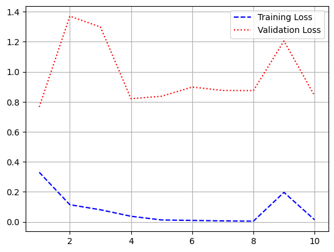

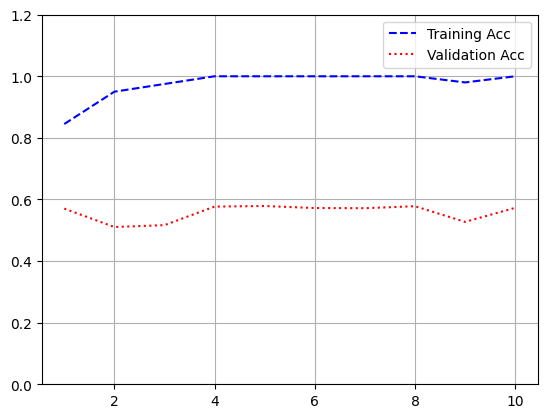

```python
loss = history.history['loss']
val_loss = history.history['val_loss']

acc = history.history['acc']
val_acc = history.history['val_acc']

epochs = range(1, len(loss) + 1)

plt.plot(epochs, loss, 'b--', label='Training Loss')
plt.plot(epochs, val_loss, 'r:', label='Validation Loss')
plt.legend()
plt.grid()

plt.figure()
plt.plot(epochs, acc, 'b--', label='Training Acc')
plt.plot(epochs, val_acc, 'r:', label='Validation Acc')
plt.ylim((0, 1.2))
plt.legend()
plt.grid()
plt.show()
```

## 사전 훈련된 단어 임베딩을 사용하지 않고 같은 모델 훈련

```python
model2 = Sequential()

model2.add(Embedding(max_words, embedding_dim, input_length=max_len))
model2.add(Flatten())
model2.add(Dense(32, activation='relu'))
model2.add(Dense(1, activation='sigmoid'))
```

```python
model2.compile(optimizer='rmsprop',
              loss='binary_crossentropy',
              metrics=['acc'])
```

```python
history2 = model2.fit(x_train, y_train,
                    epochs=10,
                    batch_size=32,
                    validation_data=(x_val, y_val), verbose=False)
```

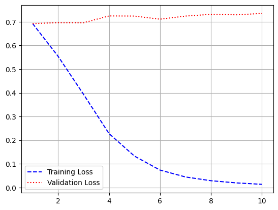

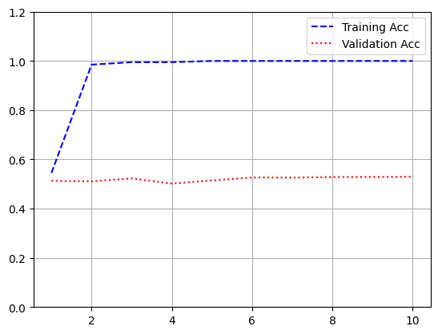

```python
loss = history2.history['loss']
val_loss = history2.history['val_loss']

acc = history2.history['acc']
val_acc = history2.history['val_acc']

epochs = range(1, len(loss) + 1)

plt.plot(epochs, loss, 'b--', label='Training Loss')
plt.plot(epochs, val_loss, 'r:', label='Validation Loss')
plt.legend()
plt.grid()

plt.figure()
plt.plot(epochs, acc, 'b--', label='Training Acc')
plt.plot(epochs, val_acc, 'r:', label='Validation Acc')
plt.ylim((0, 1.2))
plt.legend()
plt.grid()
plt.show()
```

### 테스트 데이터 토큰화

```python
test_dir = os.path.join(imdb_dir, 'test')

labels = []
texts = []

for label_type in ['neg', 'pos']:
  dir_name = os.path.join(test_dir, label_type)

  for fname in os.listdir(dir_name):
    if fname[-4:] == '.txt':
      f = open(os.path.join(dir_name, fname), encoding='utf8')
      texts.append(f.read())
      f.close()

      if label_type == 'neg':
        labels.append(0)
      else:
        labels.append(1)

sequences = tokenizer.texts_to_sequences(texts)
x_test = pad_sequences(sequences, maxlen=max_len)
y_test = np.asarray(labels)
```

```python
print(x_test.shape)
print(y_test.shape)
```

```
(25000, 100)
(25000,)
```

```python
model.load_weights('/content/pre_trained_glove_model.h5')
model.evaluate(x_test, y_test)
```

```
[0.8440878391265869, 0.5659599900245667]
```